# Evidence of cryptic and pseudocryptic speciation in the Paracalanus parvus species complex (Crustacea, Copepoda, Calanoida) | Frontiers in Zoology | Full Text

[figure not shown]

[Frontiers in Zoology](https://frontiersinzoology.biomedcentral.com/)

[Download PDF](https://frontiersinzoology.biomedcentral.com/counter/pdf/10.1186/1742-9994-11-19.pdf)

- Research
- [Open access](https://www.springernature.com/gp/open-research/about/the-fundamentals-of-open-access-and-open-research)
- Published: 02 March 2014

# Evidence of cryptic and pseudocryptic speciation in the *Paracalanus parvus* species complex (Crustacea, Copepoda, Calanoida)

- Astrid Cornils &
- Christoph Held

[*Frontiers in Zoology*](https://frontiersinzoology.biomedcentral.com/) **volume 11**, Article number: 19 (2014) Cite this article

## Abstract

### Introduction

Many marine planktonic crustaceans such as copepods have been considered as widespread organisms. However, the growing evidence for cryptic and pseudo-cryptic speciation has emphasized the need of re-evaluating the status of copepod species complexes in molecular and morphological studies to get a clearer picture about pelagic marine species as evolutionary units and their distributions. This study analyses the molecular diversity of the ecologically important *Paracalanus parvus* species complex. Its seven currently recognized species are abundant and also often dominant in marine coastal regions worldwide from temperate to tropical oceans.

### Conclusions

The present study provides evidence of cryptic or pseudocryptic speciation in the Paracalanus parvus complex. One major insight is that the species *Paracalanus parvus* s.s. is not panmictic, but may be restricted in its distribution to the northeastern Atlantic.

## Introduction

### Species delimitation and DNA barcoding

Species delimitation is a necessary process to study the life history and ecology of marine planktonic organisms, but its preciseness is dependent on the prior taxonomic knowledge. Detailed taxonomic keys may not be available for a specific region making it difficult to evaluate whether the studied specimen belongs to an already described species or an unknown species. In copepods identification is often based on only a few diagnostic characters due to the high abundances and the necessity to classify thousands of organisms [1]. These characteristics are mostly developed only in adult organisms often making it nearly impossible to identify juveniles, which are regularly more abundant than adults. Furthermore, morphological differences between sibling species may only be inconspicuous or non-existent (pseudocryptic and cryptic speciation) and thus, species may be overlooked. This phenomenon has been observed in many marine organisms (e.g. [2–4]). Cryptic speciation may be more prevalent in the marine realm than in terrestrial habitats [5].

These observations imply that traditional species concepts based on morphologically identified marine taxa may have greatly underestimated species richness [6]. Also, genetically divergent yet morphologically similar species may differ in their ecological and behavioural adaptations [7]. In general, barriers to gene flow in marine pelagic systems can often not be clearly identified (e.g. [8, 9]). To overcome these obstacles, DNA barcoding with mitochondrial gene fragments has been successfully used for species discrimination in marine plankton (e.g. [10–12]). Initially, DNA analysis using “barcoding gaps” was based on genetic distances between *a priori* defined groups and did not take into account differences in divergence times between species or other taxa and thus is questioned to be useful for DNA taxonomy (e.g. [13, 14]). However, a number of methods to measure species delimitation including DNA barcoding without defining prior groups have been published (e.g. [15–18]) These methods will be applied in the present study.

### *Paracalanus parvus* species complex

Species of the *Paracalanus parvus* complex are abundant in many marine ecosystems from temperate to tropical regions (e.g. [19–21]). Extensive research has provided valuable information on the feeding and reproduction biology of *Paracalanus parvus* (e.g. [22–24]). However, the taxonomy and species distribution of this species complex is not well understood. Currently the *P. parvus* complex consists of seven species: *P. parvus*, *P. indicus*, *P. quasimodo*, *P. nanus*, *P. intermedius*, *P.tropicus*, and *P. serrulus*. The latter may possibly belong to the *Paracalanus aculeatus* species complex [25], and *P. intermedius* may be a junior synonym of *P. parvus*[26]. The circumglobal distribution of *P. parvus* has also been questioned e.g. [24].

In the present study mitochondrial marker genes (cytochrome *c* oxidase subunit I (COI), cytochrome *b* (Cytb)) will be applied to investigate the genetic diversity of this species complex. Genetic markers are favourable as a tool to distinguish between species compared to microscopy considering that exact morphological identifications can be nearly impossible if morphological characteristics, such as antennules or exopods of swimming legs, are missing due to net sampling. We aim to define molecular operational taxonomic units (MOTUs; [27]) within the *P. parvus* species complex to establish a framework for future studies, and to elucidate their geographic boundaries.

## Material and methods

### Preservation and morphological identification

A total of 162 females of the *Paracalanus parvus* species complex from 44 samples were analysed (Additional file 1). Specimens were preserved in 96% pure ethanol with a change in ethanol after 24 hours of the initial fixation. Individuals of the *P. parvus* species complex were separated from other *Paracalanus* species such as *P. aculeatus* or *P. denudatus* due to the differences in segmentation and length of the antennules, the form of the spermatheca and the length of the inner setae on the caudal rami. Furthermore, the total length (TL), the prosome:urosome ratio (P:U), the length of the antennules (A1) relative to TL, and the shape of the forehead were noted prior to the DNA extraction (Figure 1, Additional file 2). However, some important diagnostic morphological characters can only be seen using light microscopy. Therefore, specimens from each sampling location were set aside as paratypes for detailed morphological analysis (according to e.g. [28–30]) and as para-vouchers preserved in ethanol. The latter are stored in the cooling facilities of the Alfred-Wegener-Institut. Specimens from Chinese coastal waters (Yellow Sea) were available from samples preserved in formalin and used for morphological identification only, while sequences from this region were obtained from GenBank (Table 1).

**Figure 1**

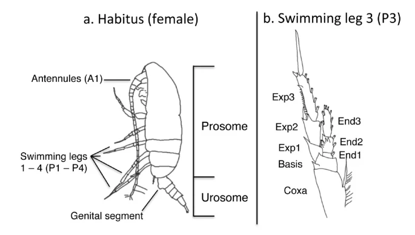

**Female specimen from the Gulf of Maine (NWA) with the important body parts for identification. a**. habitus, **b**. swimming leg 3 (Exp: Exopod, End: Endopod).

[Full size image](https://frontiersinzoology.biomedcentral.com/articles/10.1186/1742-9994-11-19/figures/1)

**Table 1 **Information on 43 COI sequences of the** *Paracalanus parvus* **species group published in GenBank****

[Full size table](https://frontiersinzoology.biomedcentral.com/articles/10.1186/1742-9994-11-19/tables/1)

Five species were identified combining the measurements of each individual prior to DNA extraction and the detailed morphological analysis of paratypes from each clade after the genetic analysis according to the morphological characteristics summarised by [34]. *Paracalanus nanus* can be distinguished from the other species by its small size and short antennules (barely reaching the end of the prosome), and the distal edges of the exopod segment 3 (Exp3) of the swimming legs 2 – 4 (P2-P4) are not serrated (Figure 1, Additional file 2). *Paracalanus tropicus* has very short urosome segments and as such a high P:U ratio. *Paracalanus indicus*, *Paracalanus parvus*, and *Paracalanus quasimodo* are distinguished by differences in the serration of the distal outer edge of the Exp3 of the P2-P4. *P. parvus* has a vaulted forehead, while a dorsalic hump on the prosome is present in *P. quasimodo. P. indicus* is characterised by posterior-dorsal spines on the female genital segment. Due to the process of net sampling, specimens were often lacking distal parts of the antennules and the swimming legs and, thus complicating the identification of the morphospecies.

### DNA extraction and amplification

DNA was extracted using the QIAamp DNA Mini Kit (Qiagen) from whole individuals and were eluted in 200 μl elution buffer (AE). DNA samples were stored at −20°C until further analysis. The mitochondrial protein coding genes COI and Cytb were sequenced using the primer sets UCYTB151F and UCYTB270R for Cytb [35], and LCO1490 and HCO2198 for COI [36], and the reverse COI primer C1-N-2191 (alias Nancy, 5`-CCCGGTAAAATTAAAATATAAACTTC-3`; [37]) for difficult specimens. PCR amplifications were performed in 25 μl reaction volumes. For Cyt *b* it included 5 μl 5x KAPA2G Buffer B, 5 μl 5x KAPA Enhancer 1, 0.125 μl of 100 μM each primer, 0.5 μl of 10 mM dNTPs, 0.15 μl of KAPA2G DNA Polymerase (5 Units/μl) and 2 μl DNA template. PCR reactions for Cytb consisted of 35 cycles of denaturation at 94°C for 40 sec, annealing at 50°C for 45 sec and extension at 72°C for 45 sec. For COI the reaction volume included 5 μl of 5x Colorless GoTaq® Flexi Buffer (Promega), 2.5 μl of 25 mM MgCl2, 0.1 μl of 100 μM each primer, 0.5 μl of 10 mM dNTPs, 0.13 μl GoTaq® Flexi DNA Polymerase (Promega) and 2 μl of DNA template. PCR reactions for COI consisted of 35 cycles of denaturation at 94°C for 40 sec, annealing at 45°C for 45 sec and extension at 69°C for 45 sec. PCR products were run on a 1% agarose/TBE gel and afterwards stained with ethidium bromide for band characterization. Positive results were purified with ExoSap-IT (0.25 μl exo, 1 μl SAP) and subsequently used for cycle sequencing with Big Dye Terminator Ver. 3.1 (Applied Biosystems Inc., ABI) and the same primers as for the PCR amplifications. The sequences were run on an ABI 3130xl DNA sequencer.

### Sequence editing

**Table 2 **Tests for species distinctivenes of the MOTUs for COI (165 sequences (including 43 GenBank sequences))****

[Full size table](https://frontiersinzoology.biomedcentral.com/articles/10.1186/1742-9994-11-19/tables/2)

Identical sequences were merged to unique haplotypes (Table 2) with Mesquite Ver. 2.75 [38]. Out of the 162 individuals analysed, 122 (COI) or 131 (Cytb) specimens could be extracted and amplified. The 165 sequences of COI (including 43 sequences from Genbank) could be placed in 87 haplotypes and the 131 Cytb sequences could be attributed to 49 haplotypes (Table 2, Additional file 3). Sequences are published in GenBank (KF715875 – KF715996; KF715999 – KF716129; Additional file 1). All COI sequences had a minimum length of 400 bp, and 91.2% had more than 600 bp.

### Tests for pseudogenes

Some COI sequences could not be sequenced due to double bands in the agarose gel. For a few other COI sequences, no consensus sequence could be built. Others produced highly divergent sequences (single sequences that differ extraordinarily from the alignment). These could be signs of either heteroplasmy, the presence of pseudogenes, contaminations, or the nonspecific binding of at least one primer under less stringent PCR conditions. All outlier sequences were excluded from the analyses. These difficulties were not found in Cytb. In the final alignments, no stop codons or indels (insertions-deletions) could be detected which would be indications for pseudogenes or incomplete lineage sorting [39, 40]. The diversity for each codon position separately was also checked [41] using MEGA 5.2.2 [42]. In mitochondrial genes the diversity should be higher in the third codon position, while in pseudogenes the diversity would be equally distributed in all three codon positions. For COI the diversity varied between all three positions (1st position: 0.0579 ± 0.0091; 2nd position: 0.0006 ± 0.0002; 3rd position: 0.3319 ± 0.0136) and similar variations were found for Cytb (1st position: 0.0602 ± 0.0128; 2nd position: 0.0195 ± 0.0088; 3rd position: 0.3165 ± 0.0191). Furthermore, 392 of 647 positions of the COI data set and 214 of 351 positions of the Cytb data set were conserved. All these tests indicate the absence of pseudogenes in the final alignment. However, pseudogenes may be very similar to the targeted mitochondrial gene and thus be overlooked.

### Sequence analysis

The alignments of the haplotypes were used to infer Maximum Likelihood (ML) phylogenetic trees carried out with RAxML Vers. 7.2.8 [43] and Bayesian Inference (BI) calculated with MrBayes Vers. 3.2 [44]. The analyses were completed with un-partitioned nucleotides sequences, and with partitioned datasets accounting for the different substitution rates in the three codon positions. RAxML was run under the option GTRGAMMA and a complete random starting tree for the 10000 bootstrap replicates [45]. Then, a best-known likelihood tree search (500 inferences) was performed under GTRMIX and a completely random starting tree. The final tree topology was evaluated under GTRGAMMA to yield stable likelihood values. For the Bayesian Inference the nucleotide substitution model was selected with jModeltest Vers. 2.3 [46, 47] using the Akaike information criterion (AIC) for small sample sizes. The best-fitted model (GTR + I + G) was then implemented in MrBayes. The analysis was run for 3,000,000 generations for the unpartitioned data set and for 10,000,000 generations for the codon model with a sample frequency of 1,000 generations. The first 500 trees were discarded as burn-in. Clade support is shown on the nodes of the trees as the Bayesian Posterior Probability (BPP) when BPP > 0.90.

As outgroup *Delibus* spp. from the family Paracalanidae were chosen (COI: Accession numbers JQ911978 (*Delibus nudus*); JQ911979, KF715873, KF715874 (*Delibus* sp.); Cytb: KF715997, KF715998 (*Delibus* sp.)). The analysis of the phylogeny of the family Paracalanidae has shown that the genus *Delibus* has the closest relationship to the *Paracalanus parvus* complex [32].

For presumably recently diverged lineages that were separated with some species delimitation methods haplotype networks were created with TCS Vers. 1.2.1 [48] to demonstrate the geographic structure of the haplotypes.

### Species delimitation methods

Two independent methods of species delimitation were applied to propose a first species hypothesis for the *Paracalanus parvus* complex: Automated Barcoding Gap Discovery (ABGD) and the generalized mixed Yule coalescent model (GMYC).

Automatic Barcode Gap Discovery (ABGD) is an automated iterative process to sort sequences into putative species based on pairwise distances without an *a priori* species hypothesis [17]. This algorithm automatically detects significant differences between intra- and inter-specific variations (i.e. barcoding gap). Aligned sequences of all haplotypes were uploaded to the web interface at http://wwwabi.snv.jussieu.fr/public/abgd/abgdweb.html and were run with the default settings. P (prior limit to intraspecific diversity) had a minimum value of 0.001 and a maximum value of 0.1. The relative gap width (X) had a value of 1. All available models (Jukes-Cantor (JC86), Kimura (K80)) were tested.

The generalized mixed Yule coalescent model (GMYC) infers species boundaries by measuring the transition from intra- to inter-species branching patterns [16]. This method combines models of stochastic lineage growth (Yule models) with coalescence theory. The analysis is implemented in R as part of the package “splits” (SPecies LImits by Threshold Statistics; [49]). The explanatory power of a model assuming a transition from population-specific to more phylogeny-like branching patterns is compared to a null model (all specimens are derived from a single species). The GMYC method was applied allowing a single threshold [50]. Prior to the analysis, outgroups were removed and the unique haplotypes were used to render an ultrametric consensus tree as starting point for the GMYC model (BEAST Vers. 1.7.4 [51]). A relaxed uncorrelated log-normal clock was chosen with a mean substitution rate fixed at 1 and estimated branch length with a coalescent prior. MCMC chains were run for 10 million generations sampling every 1,000 steps after a burn-in period of 1,000 trees.

As the both methods are sensitive to intra-species sampling we additionally analysed species delimitation for an alignment of all 165 specimens.

To test whether the MOTUs derived from the ABGD and GMYC analyses represent putative species, several species delimitation methods were applied. The resulting MOTUs were similar for the two gene fragments. Therefore, only the COI results are presented, since this gene fragment is frequently used to identify species (i.e. DNA barcoding; [52]), and distance thresholds can be compared to those of other copepods. Cytb results are found in the supplementary material. The methods all calculated species delimitation without *a priori* defined groups and are all based on uncorrected pairwise distance calculated with MEGA Vers. 5.2.2 unless otherwise indicated, since the use of K2P distance for DNA barcoding analysis is under debate [53]. Colour heat maps representing the distances between all haplotypes were plotted in MATLAB (base installation of R2013b, The MathWorks Inc.).

Barcode gaps between well-supported clades of haplotypes identified by Maximum Likelihood and Bayesian Inferences were taken as an indication of separate MOTUs. To find the optimal thresholds for intra-specific p-distances, the function localMinima of the SPIDER (SPecies IDentity and Evolution in R) Vers. 1.2 package for R ([http://www.R-project.org](http://www.r-project.org/)) was used [54]. Based on the concept of the barcoding gap, this method indicates the transition between intra- and interspecific genetic distances from a dip in the density of the uncorrected p-distances without prior knowledge of species identity [54] and provides thresholds. These were used to cluster the sequences with the software jMOTU [15].

Rosenberg’s P(*AB*) examines whether monophyly has been produced by evolutionary processes or by insufficient sampling and calculates the probability that a MOTU with by *A* haplotypes is monophyletic to its closest relative with *B* haplotypes [18]. Significance of nodes was visualized with the R package SPIDER using a consensus ultrametric tree built in BEAST.